compiled on February 10, 2020

# RchivalTag Package Tutorial

Part 3 - Daily Depth-Temperature profiles

Dr. Robert Bauer | Data Scientist & Fishery Biologist

- 1. Hawai’i Institute of Marine Biology, University of Hawai’i at Mānoa, Kāne’ohe, Hawai’i, United States of America  
     rkbauer@hawaii.edu  
     https://orcid.org/0000-0003-4224-8023

### Getting started:

```r
## install or load package
# install.packages("RchivalTag")
library("RchivalTag")

## Package overview:
?RchivalTag
help(package="RchivalTag") ## list of functions
```

### The 3 Options to illustrate depth temperature data

In the 2nd tutorial we already covered different ways to illustrate depth temperature data from archival tags such as

1. line plots with one y-axis for the depth time series data and a second y-axis for the temperature time series data
2. coloring of the corresponding temperature values of the depth time series records as points or interpolated line plot.

Another, third option represents the daily depth-temperature profiles that can be obtained from depth-temperature time series data or PAT-Style depth temperature profiles.

### PAT-Style depth-temperature profiles (PDT data):

PAT depth temperature profiles are a special summary product from WC. They return the minimum and maximum temperature in the 8 to 16 depth bins. The bin size is always 8 m. The selection and number of depth bins depends on the behavior of the fish. If the tag went deeper than 400 m, 16 depth bins are selected, otherwise only 8. The upper and lower most depth bins are always included. The remaining 6 to 14 bins depend on the behavior preferences of the fish. Unfortunately this can influence the value of the PDT data. In case of epipelagic fish (that frequent the waters from the surface to the bottom of the thermocline and beyond), we can infer some useful information about the thermal stratification. But first, let’s have a look on the format of a PDT file:

```r
path <- system.file("example_files",package="RchivalTag")
setwd(path)
PDT_raw <- read.csv("104659-PDTs.csv")
names(PDT_raw)
```

```
##  [1] "DeployID"        "Ptt"             "DepthSensor"     "Source"
##  [5] "Instr"           "Date"            "Time.Offset"     "Count"
##  [9] "LocationQuality" "Latitude"        "Longitude"       "BadTherm"
## [13] "NumBins"         "Partial"         "Depth1"          "MinTemp1"
## [17] "MaxTemp1"        "X.Ox1"           "Discont1"        "Depth2"
## [21] "MinTemp2"        "MaxTemp2"        "X.Ox2"           "Discont2"
## [25] "Depth3"          "MinTemp3"        "MaxTemp3"        "X.Ox3"
## [29] "Discont3"        "Depth4"          "MinTemp4"        "MaxTemp4"
## [33] "X.Ox4"           "Discont4"        "Depth5"          "MinTemp5"
## [37] "MaxTemp5"        "X.Ox5"           "Discont5"        "Depth6"
## [41] "MinTemp6"        "MaxTemp6"        "X.Ox6"           "Discont6"
## [45] "Depth7"          "MinTemp7"        "MaxTemp7"        "X.Ox7"
## [49] "Discont7"        "Depth8"          "MinTemp8"        "MaxTemp8"
## [53] "X.Ox8"           "Discont8"        "Depth9"          "MinTemp9"
## [57] "MaxTemp9"        "X.Ox9"           "Discont9"        "Depth10"
## [61] "MinTemp10"       "MaxTemp10"       "X.Ox10"          "Discont10"
## [65] "Depth11"         "MinTemp11"       "MaxTemp11"       "X.Ox11"
## [69] "Discont11"       "Depth12"         "MinTemp12"       "MaxTemp12"
## [73] "X.Ox12"          "Discont12"       "Depth13"         "MinTemp13"
## [77] "MaxTemp13"       "X.Ox13"          "Discont13"       "Depth14"
## [81] "MinTemp14"       "MaxTemp14"       "X.Ox14"          "Discont14"
## [85] "Depth15"         "MinTemp15"       "MaxTemp15"       "X.Ox15"
## [89] "Discont15"       "X"               "X.1"             "X.2"
## [93] "X.3"             "X.4"
```

We can see that all depth bins as well as the corresponding minimum and maximum temperature values are listed next to each other in the header of the PDT file. To transform this into a meaningful data.frame, RchivalTag comes with its own function to read and convert PDT files:

```r
PDT <- read_PDT("104659-PDTs.csv",folder=path)
## running pdt_file /home/work/R/x86_64-pc-linux-gnu-library/3.6/RchivalTag/example_files/104659-PDTs.csv
str(PDT,1)
```

```
## 'data.frame':    127 obs. of  10 variables:
##  $ pdt_file: Factor w/ 1 level "/home/work/R/x86_64-pc-linux-gnu-library/3.6/RchivalTag/example_files/104659-PDTs.csv": 1 1 1 1 1 1 1 1 1 1 ...
##  $ DeployID: chr  "15P1019" "15P1019" "15P1019" "15P1019" ...
##  $ Ptt     : int  104659 104659 104659 104659 104659 104659 104659 104659 104659 104659 ...
##  $ NumBins : int  8 8 8 8 8 8 8 8 16 16 ...
##  $ Depth   : num  0 24 104 176 192 288 328 384 0 16 ...
##  $ MinTemp : num  18 15 13.4 13.4 13.4 13.6 13.6 13.6 21.4 16.4 ...
##  $ MaxTemp : num  23.2 21.8 14 13.8 13.8 13.8 13.6 13.6 23.8 22.4 ...
##  $ datetime: POSIXlt, format: "2016-08-07 08:00:00" "2016-08-07 08:00:00" ...
##  $ date    : Date, format: "2016-08-07" "2016-08-07" ...
##  $ MeanPDT : num  20.6 18.4 13.7 13.6 13.6 13.7 13.6 13.6 22.6 19.4 ...
```

This looks better. We have now all depth bins and related temperature values as well as the mean temperature from the minimum and maximum temperature listed in rows. The latter is not exactly the average temperature of a depth bin, but often close to it.

Like other summary products the number of PDTs per day depends on the summary period (6h, 12h, 24h). Our PDT file had a 24h summary period (which we can see from the datetime values).

The PDT data itself is not yet really helpful, but we can interpolate the MeanPDT temperature values and visualize the resulting profile. RchivalTag comes with 2 functions to do this. First we interpolate the data:

```r
m <- interpolate_PDTs(PDT, show_info=F)
str(m,2)
```

```
## List of 1
##  $ station.1:List of 4
##   ..$ Temperature_matrix: num [1:961, 1:15] 20.6 20.6 20.5 20.5 20.4 ...
##   ..$ Depth             : num [1:961] 0 0.5 1 1.5 2 2.5 3 3.5 4 4.5 ...
##   ..$ Date              : Date[1:15], format: "2016-08-07" "2016-08-08" ...
##   ..$ sm                :'data.frame':   15 obs. of  3 variables:
```

The result is a list of stations with each station corresponding to a specific tag in the PDT file (In some cases there are several tags in one PDT file). Each station comes with a temperature matrix that is defined by the depth and date values.

We can visualize the daily interpolated depth temperature profiles by running the next chunk of code.

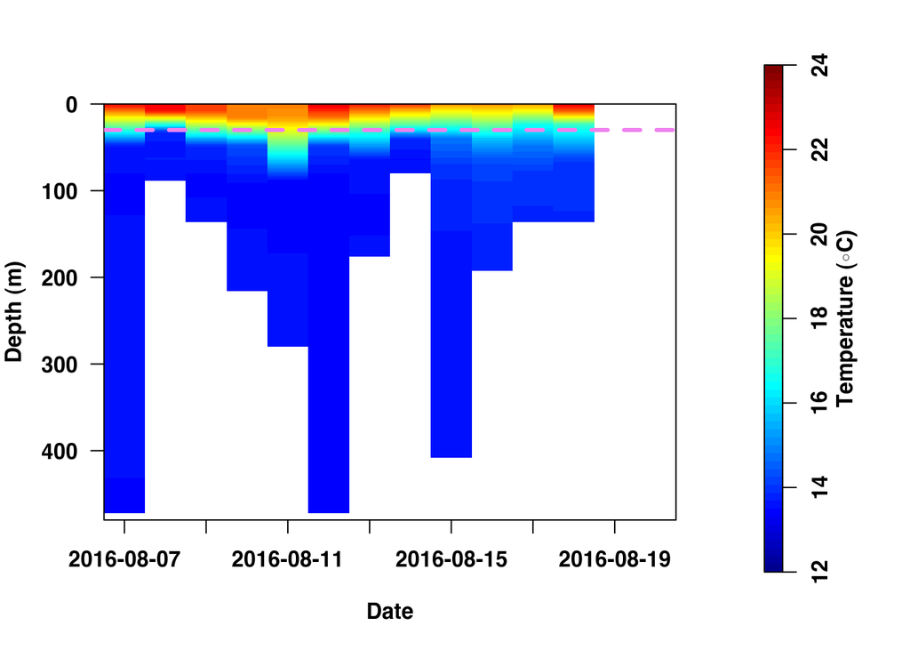

```r
image_TempDepthProfiles(m[[1]])
abline(h=30,lty="dashed",col="violet",lwd=3)
```

We could add some external data, like the average depth of our tagged animal on top:

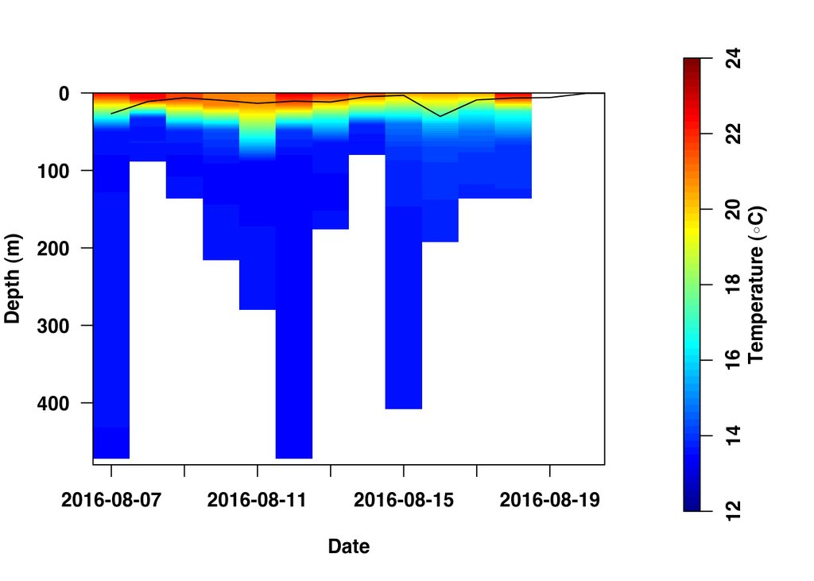

```r
image_TempDepthProfiles(m[[1]])

ts_file <- system.file("example_files/104659-Series.csv",package="RchivalTag")
ts_df <- read_TS(ts_file)
library(plyr)
ts_stats <- ddply(ts_df,c("date"),function(x) c(avg=mean(x$Depth,na.rm=T), SD=sd(x$Depth,na.rm=T)))
lines(ts_stats$date+.5,ts_stats$avg)
```

### Thermal stratification indicators

This does not look not bad. It appears that our fish spent most of the time above the thermocline. But what is the depth of the thermocline? There are several definitions to estimate the thermocline and other thermal stratification indicators. RchivalTag can estimate several thermal stratification indicators from interpolated depth temperature profiles such as:

1. tgrad - thermocline gradient (maximum temperature gradient)
2. tcline - thermocline depth (depth corresponding to tgrad)
3. mld, mld_0.5, mld_0.8 - different mixed layer depth definitions
4. strat_index - stratification index (standard deviation of temperature values up to a defined depth)

For more details and references, please see the documentation of the `get_thermalstrat` function.

```r
# ?get_thermalstrat ## check documentation
strat <- get_thermalstrat(m, all_info = T)
## 6.7% done
## 13.3% done
## 20% done
## 26.7% done
## 33.3% done
## 40% done
## 46.7% done
## 53.3% done
## 60% done
## 66.7% done
## 73.3% done
## 80% done
## 86.7% done
head(strat)
```

```
##         Date nrecs                                                     Depths
## 1 2016-08-07     8                               0;24;104;176;192;288;328;384
## 2 2016-08-08    16 0;16;48;80;128;160;176;208;240;272;304;336;368;424;432;472
## 3 2016-08-09     7                                         0;8;32;48;64;72;88
## 4 2016-08-10     8                                    0;8;24;48;80;96;120;136
## 5 2016-08-11     8                                 0;16;48;96;128;144;200;216
## 6 2016-08-12     8                                 0;16;88;96;152;192;224;280
##   maxDepth_interp    tgrad   tcline dz  mld mld_0.5 mld_0.8 strat_index
## 1           384.5 1.833333 12.00000 20  0.0       5       9    1.855061
## 2           472.5 3.912500 10.00000 20  0.0       2       4    2.870580
## 3            88.5 7.000000 19.75000 20  9.5       9      10    3.158587
## 4           136.5 3.916667 36.33333 20 25.5      11      12    2.978175
## 5           216.5 4.125000 31.57692 20 16.0      18      20    2.897268
## 6           280.5 1.972222 48.98077 20 22.5      18      21    2.602092
##   strat_lim        ID
## 1       100 station.1
## 2       100 station.1
## 3       100 station.1
## 4       100 station.1
## 5       100 station.1
## 6       100 station.1
```

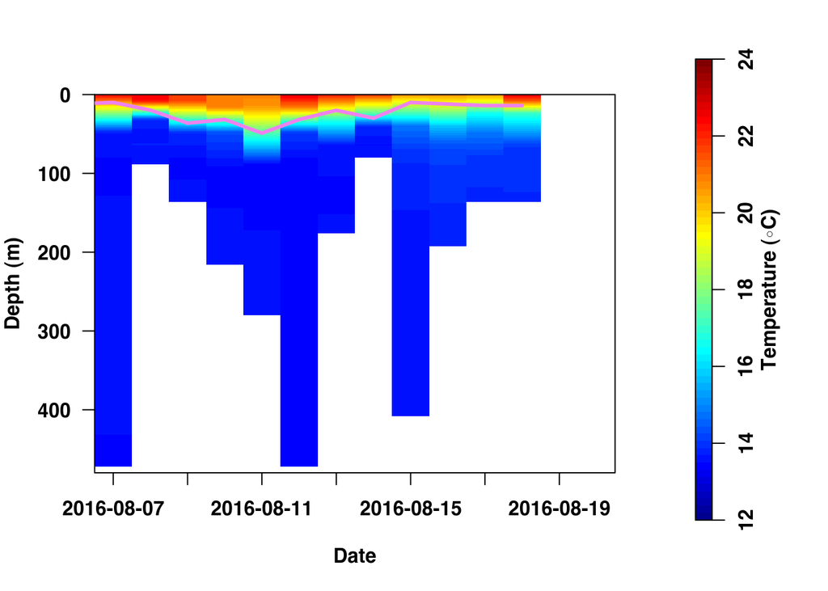

```r
image_TempDepthProfiles(m[[1]])
lines(strat$Date-.5,strat$tcline,col="violet",lwd=3)
```

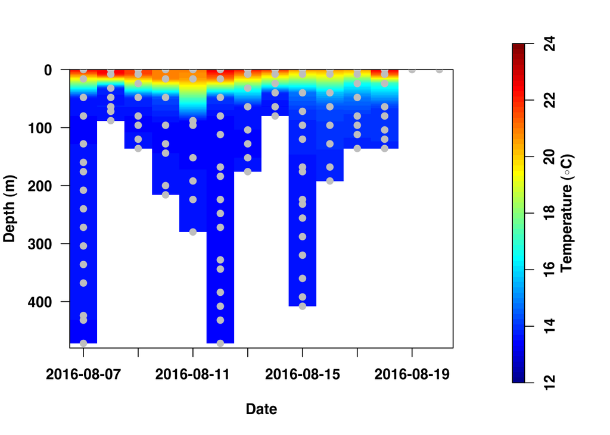

```r
image_TempDepthProfiles(m[[1]])
points(PDT$date-.5,PDT$Depth,pch=19, col="grey")
```

### Daily depth-temperature profiles from time series data

Another more accurate way, is to interpolate the depth-temperature time series data. The loaded PDT data actually resembles this type of data.

```r
# ## step I) read sample time series data file:
ts_file <- system.file("example_files/104659-Series.csv",package="RchivalTag")
DepthTempTS <- read_TS(ts_file)
M <- interpolate_TempDepthProfiles(DepthTempTS)
```

```
## [1] "station 1 - set: 2016-08-07"
## [1] "station 1 - set: 2016-08-08"
## [1] "station 1 - set: 2016-08-09"
## [1] "station 1 - set: 2016-08-10"
## [1] "station 1 - set: 2016-08-11"
## [1] "station 1 - set: 2016-08-12"
## [1] "station 1 - set: 2016-08-13"
## [1] "station 1 - set: 2016-08-14"
## [1] "station 1 - set: 2016-08-15"
## [1] "station 1 - set: 2016-08-16"
## [1] "station 1 - set: 2016-08-17"
## [1] "station 1 - set: 2016-08-18"
## [1] "station 1 - set: 2016-08-19"
## [1] "station 1 - set: 2016-08-20"
## [1] "station 1 - set: 2016-08-21"
```

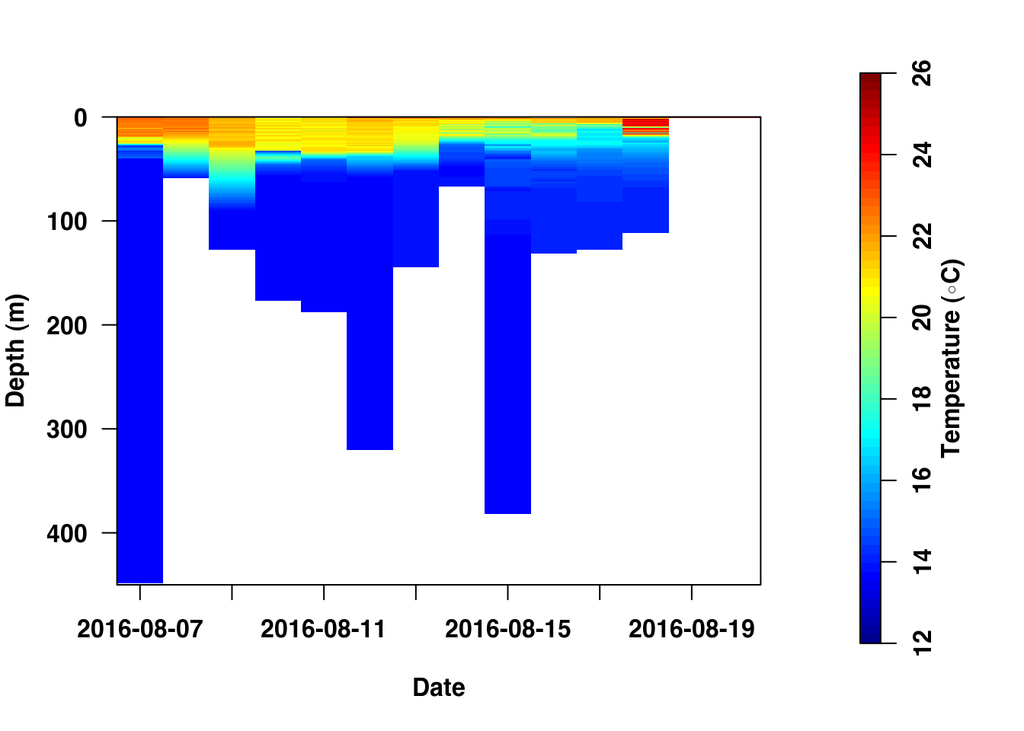

```r
image_TempDepthProfiles(M[[1]])
```

In the example above, we see a lot of small temperature changes in the upper 50 m. This is an artifact of the interpolation process and the data resolution. The time series data in the example above is a transmitted data set with a temporal resolution of 10 min. As a consequence, many depth-temperature values between the different sampling points are missing, resulting in the interpolation of distant temperature values, like in the PDT data earlier. Moreover, since the fish moves between different water masses, certain depths were sampled less than others, which contributes to this bias. We can avoid this, by binning the data similar to the PDT data:

```r
binned_ts <- bin_TempTS(DepthTempTS,res=10)
```

```
## [1] "2016-08-07"
## [1] "2016-08-08"
## [1] "2016-08-09"
## [1] "2016-08-10"
## [1] "2016-08-11"
## [1] "2016-08-12"
## [1] "2016-08-13"
## [1] "2016-08-14"
## [1] "2016-08-15"
## [1] "2016-08-16"
## [1] "2016-08-17"
## [1] "2016-08-18"
## [1] "2016-08-19"
## [1] "2016-08-20"
## [1] "2016-08-21"
```

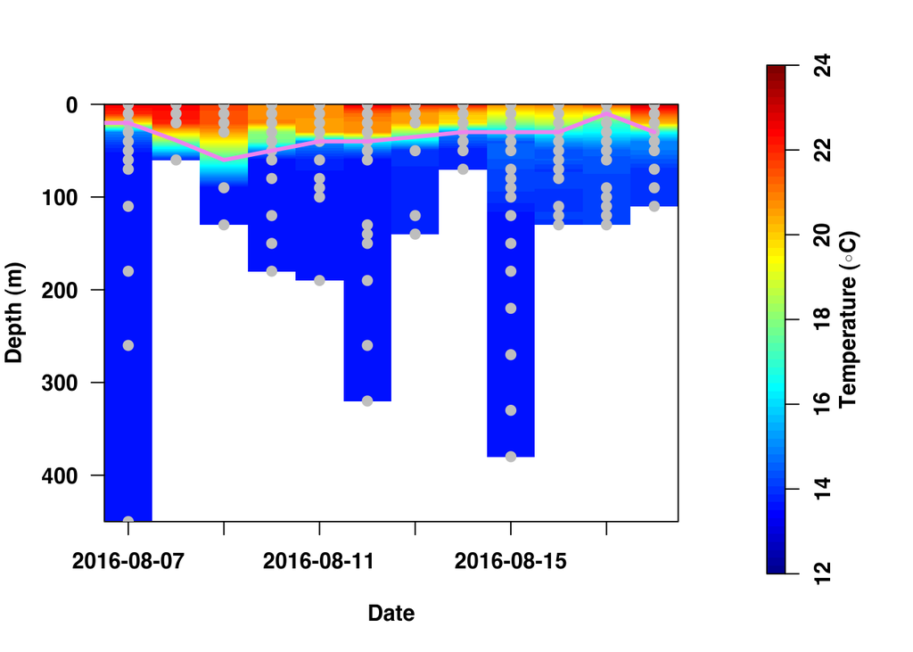

```r
M2 <- interpolate_TempDepthProfiles(binned_ts,"MeanPDT", show_info = F)
image_TempDepthProfiles(M2[[1]])
points(binned_ts$date-.5,binned_ts$Depth,pch=19, col="grey")

strat2 <- get_thermalstrat(M2, all_info = T)
## 7.7% done
## 15.4% done
## 23.1% done
## 30.8% done
## 38.5% done
## 46.2% done
## 53.8% done
## 61.5% done
## 69.2% done
## 76.9% done
## 84.6% done
## 92.3% done
## 100% done
lines(strat2$Date-.5,strat2$tcline,col="violet",lwd=3)
```

The result looks quite similar. In terms of accuracy, the stratication index is less biased, and recommended for further use (e.g. in ecological modelling).

### Resampling temperature data from PDT data:

In the 2nd tutorial, we already saw how to visualize thermal profiles directly within the time series data based on resamples from interpolated PDT data.

```
## [1] "station 1 - set: 2016-08-07"
## [1] "station 1 - set: 2016-08-08"
## [1] "station 1 - set: 2016-08-09"
## [1] "station 1 - set: 2016-08-10"
## [1] "station 1 - set: 2016-08-11"
## [1] "station 1 - set: 2016-08-12"
## [1] "station 1 - set: 2016-08-13"
## [1] "station 1 - set: 2016-08-14"
## [1] "station 1 - set: 2016-08-15"
## [1] "station 1 - set: 2016-08-16"
## [1] "station 1 - set: 2016-08-17"
## [1] "station 1 - set: 2016-08-18"
## [1] "station 1 - set: 2016-08-19"
## [1] "station 1 - set: 2016-08-20"
## [1] "station 1 - set: 2016-08-21"
```

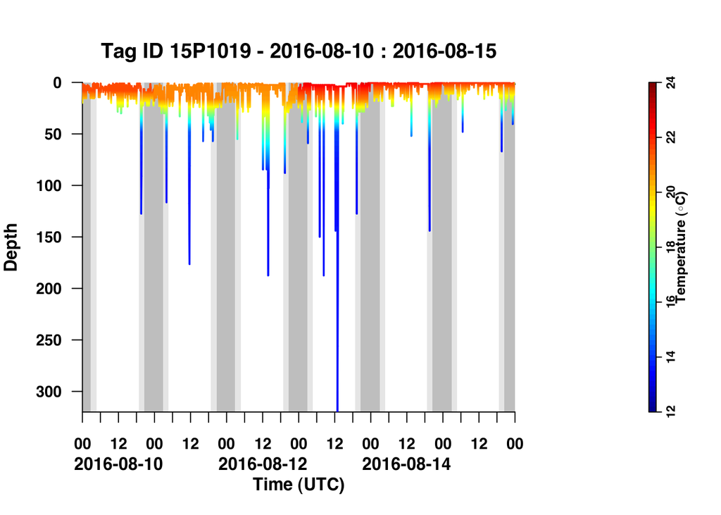

```r
ts_file <- system.file("example_files/104659-Series.csv",package="RchivalTag")
ts_df <- read_TS(ts_file)
ts_df$Temperature <- c()

ts_df$Lon <- 5; ts_df$Lat <- 43 # manual example, please take Lon/Lat data from (GPE3) model outputs for your analysis instead. (check get_geopos-function from RchivalTag)
ts_df <- classify_DayTime(ts_df)

pdt_file <- system.file("example_files/104659-PDTs.csv",package="RchivalTag")
PDT <- read_PDT(pdt_file)
## running pdt_file /home/work/R/x86_64-pc-linux-gnu-library/3.6/RchivalTag/example_files/104659-PDTs.csv

library(oceanmap)
data(cmap)
plot_DepthTempTS_resampled_PDT(ts_df,PDT,xlim = c("2016-08-10","2016-08-15"),plot_DayTimePeriods = T)
```

### Time-at-Temperature histograms from PDT data:

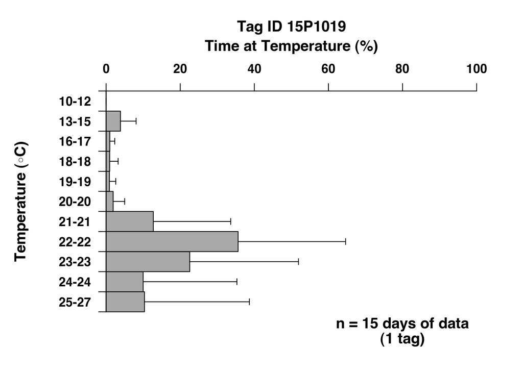

```r
ts_file <- system.file("example_files/104659-Series.csv",package="RchivalTag")
ts_df <- read_TS(ts_file)

path <- system.file("example_files",package="RchivalTag")
PDT <- read_PDT("104659-PDTs.csv",folder=path)
## running pdt_file /home/work/R/x86_64-pc-linux-gnu-library/3.6/RchivalTag/example_files/104659-PDTs.csv

m <- interpolate_PDTs(PDT,show_info = F)[[1]]
# image_TempDepthProfiles(m)

out <- c()
for(i in 1:length(m$Date)){
  Temp <- m$Temperature_matrix[,i]
  add <- data.frame(date=m$Date[i],Depth=m$Depth,Temperature=Temp)
  out <- rbind(out, add)
}

input <- ts_df; input$Temperature <- c()
ts_PDT <- merge(input, out, by=c("date", "Depth"), all.x=T)
tat_breaks <- c(10,12,15,17,18,19,20,21,22,23,24,27)

hist_tat(ts_df, bin_breaks = tat_breaks) ## time series data
```

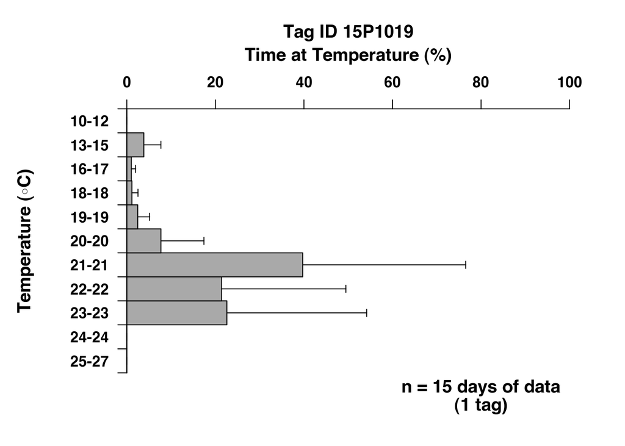

```r
hist_tat(ts_PDT, bin_breaks = tat_breaks) ## PDT data
```

### Summary:

In this tutorial we saw the informational value and limitations of PDT and low resolution depth-temperature time series data. While the informational value and limitations of both data types are comparable, the selection of PDT data instead of temperature time series data increases the battery capacity and thus transmission success of pop-up archival tags. The paper by (Bauer, Forget, and Fromentin 2015) is highly recommended in this context.

## References:

Bauer, Robert Klaus; Fabien; Forget, and Jean-Marc Fromentin. 2015. “Optimizing PAT data transmission - assessing the accuracy of temperature summary data to estimate environmental conditions.” *Fisheries Oceanography* 24 (6): 533–39. https://doi.org/10.1111/fog.12127.